# Introductory Econometrics Examples

Justin M Shea

**My Notes**  
This is an example file of preparing **html_vignette** document. The original is located at the website [https://justinmshea.github.io/wooldridge/articles/Introductory-Econometrics-Examples.html#chapter-9-more-on-specification-and-data-issues-1] and the raw file is located at the website [https://github.com/JustinMShea/wooldridge/blob/master/vignettes/Introductory-Econometrics-Examples.Rmd].

## Introduction

This vignette reproduces examples from various chapters of *Introductory Econometrics: A Modern Approach, 7e* by Jeffrey M. Wooldridge. Each example illustrates how to load data, build econometric models, and compute estimates with **R**.

In addition, the **Appendix** cites a few sources using **R** for econometrics. Of note, in 2020 Florian Heiss published a 2nd edition of [*Using R for Introductory Econometrics*](http://www.urfie.net/); it is excellent. The Heiss text is a companion to wooldridge for `R` users, and offers an in depth treatment with several worked examples from each chapter. Indeed, his example use this `wooldridge` package as well.

Now, install and load the `wooldridge` package and lets get started!

```r
install.packages("wooldridge")
```

```r
library(wooldridge)
```

## Chapter 2: The Simple Regression Model

### **`Example 2.10:` A Log Wage Equation**

Load the `wage1` data and check out the documentation.

```r
data("wage1")

?wage1
```

The documentation indicates these are data from the 1976 Current Population Survey, collected by Henry Farber when he and Wooldridge were colleagues at MIT in 1988.

**$educ$:** years of education

**$wage$:** average hourly earnings

**$lwage$:** log of the average hourly earnings

First, make a scatter-plot of the two variables and look for possible patterns in the relationship between them.

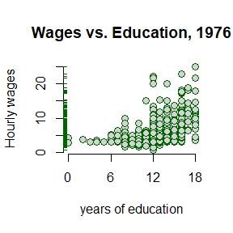

It appears that **on average**, more years of education, leads to higher wages.

The example in the text is interested in the *return to another year of education*, or what the **percentage** change in wages one might expect for each additional year of education. To do so, one must use the $log($`wage`$)$. This has already been computed in the data set and is defined as `lwage`.

The textbook provides excellent discussions around these topics, so please consult it.

Build a linear model to estimate the relationship between the *log of wage* (`lwage`) and *education* (`educ`).

$$\widehat{log(wage)} = \beta_0 + \beta_1educ$$

```r
log_wage_model <- lm(lwage ~ educ, data = wage1)
```

Print the `summary` of the results.

```r
summary(log_wage_model)
```

|  | *Dependent variable:* |
| --- | --- |
|  | lwage |
| educ | 0.08274*** (0.00757) |
| Constant | 0.58377*** (0.09734) |
| Observations | 526 |
| R<sup>2</sup> | 0.18581 |
| Adjusted R<sup>2</sup> | 0.18425 |
| Residual Std. Error | 0.48008 (df = 524) |
| F Statistic | 119.58160*** (df = 1; 524) |
| *Note:* | p<0.1; p<0.05; p<0.01 |

Plot the $log($`wage`$)$ vs `educ`. The blue line represents the least squares fit.

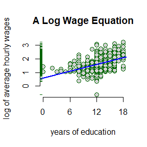

## Chapter 3: Multiple Regression Analysis: Estimation

### **`Example 3.2:` Hourly Wage Equation**

Check the documentation for variable information

```r
?wage1
```

**$lwage$:** log of the average hourly earnings

**$educ$:** years of education

**$exper$:** years of potential experience

**$tenutre$:** years with current employer

Plot the variables against `lwage` and compare their distributions and slope ($\beta$) of the simple regression lines.

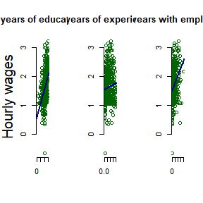

Estimate the model regressing *educ*, *exper*, and *tenure* against *log(wage)*.

$$\widehat{log(wage)} = \beta_0 + \beta_1educ + \beta_3exper + \beta_4tenure$$

```r
hourly_wage_model <- lm(lwage ~ educ + exper + tenure, data = wage1)
```

Print the estimated model coefficients:

```r
coefficients(hourly_wage_model)
```

|  | Coefficients |
| --- | --- |
| (Intercept) | 0.2844 |
| educ | 0.0920 |
| exper | 0.0041 |
| tenure | 0.0221 |

Plot the coefficients, representing percentage impact of each variable on $log($`wage`$)$ for a quick comparison.

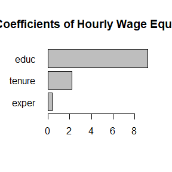

## Chapter 4: Multiple Regression Analysis: Inference

### **`Example 4.1` Hourly Wage Equation**

Using the same model estimated in **`example: 3.2`**, examine and compare the standard errors associated with each coefficient. Like the textbook, these are contained in parenthesis next to each associated coefficient.

```r
summary(hourly_wage_model)
```

|  | *Dependent variable:* |
| --- | --- |
|  | lwage |
| educ | 0.09203*** (0.00733) |
| exper | 0.00412** (0.00172) |
| tenure | 0.02207*** (0.00309) |
| Constant | 0.28436*** (0.10419) |
| Observations | 526 |
| R<sup>2</sup> | 0.31601 |
| Adjusted R<sup>2</sup> | 0.31208 |
| Residual Std. Error | 0.44086 (df = 522) |
| F Statistic | 80.39092*** (df = 3; 522) |
| *Note:* | p<0.1; p<0.05; p<0.01 |

For the years of experience variable, or `exper`, use coefficient and Standard Error to compute the $t$ statistic:

$$t_{exper} = \frac{0.004121}{0.001723} = 2.391$$

Fortunately, `R` includes $t$ statistics in the `summary` of model diagnostics.

```r
summary(hourly_wage_model)$coefficients
```

|  | Estimate | Std. Error | t value | Pr(>\|t\|) |
| --- | --- | --- | --- | --- |
| (Intercept) | 0.28436 | 0.10419 | 2.72923 | 0.00656 |
| educ | 0.09203 | 0.00733 | 12.55525 | 0.00000 |
| exper | 0.00412 | 0.00172 | 2.39144 | 0.01714 |
| tenure | 0.02207 | 0.00309 | 7.13307 | 0.00000 |

Plot the $t$ statistics for a visual comparison:

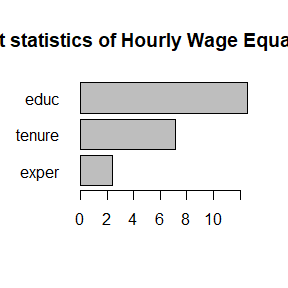

### **`Example 4.7` Effect of Job Training on Firm Scrap Rates**

Load the `jtrain` data set.

```r
data("jtrain")
```

```r
?jtrain
```

From H. Holzer, R. Block, M. Cheatham, and J. Knott (1993), *Are Training Subsidies Effective? The Michigan Experience*, Industrial and Labor Relations Review 46, 625-636. The authors kindly provided the data.

**$year:$** 1987, 1988, or 1989

**$union:$** =1 if unionized

**$lscrap:$** Log(scrap rate per 100 items)

**$hrsemp:$** (total hours training) / (total employees trained)

**$lsales:$** Log(annual sales, $)

**$lemploy:$** Log(umber of employees at plant)

First, use the `subset` function and it’s argument by the same name to return observations which occurred in **1987** and are not **union**. At the same time, use the `select` argument to return only the variables of interest for this problem.

```r
jtrain_subset <- subset(jtrain, subset = (year == 1987 & union == 0),
                        select = c(year, union, lscrap, hrsemp, lsales, lemploy))
```

Next, test for missing values. One can “eyeball” these with R Studio’s `View` function, but a more precise approach combines the `sum` and `is.na` functions to return the total number of observations equal to `NA`.

```r
sum(is.na(jtrain_subset))
```

```
## [1] 156
```

While `R`’s `lm` function will automatically remove missing `NA` values, eliminating these manually will produce more clearly proportioned graphs for exploratory analysis. Call the `na.omit` function to remove all missing values and assign the new `data.frame` object the name **`jtrain_clean`**.

```r
jtrain_clean <- na.omit(jtrain_subset)
```

Use `jtrain_clean` to plot the variables of interest against `lscrap`. Visually observe the respective distributions for each variable, and compare the slope ($\beta$) of the simple regression lines.

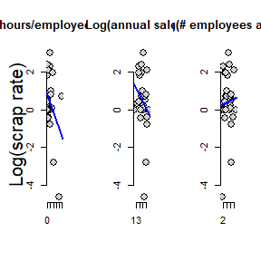

Now create the linear model regressing `hrsemp`(total hours training/total employees trained), `lsales`(log of annual sales), and `lemploy`(the log of the number of the employees), against `lscrap`(the log of the scrape rate).

$$lscrap = \alpha + \beta_1 hrsemp + \beta_2 lsales + \beta_3 lemploy$$

```r
linear_model <- lm(lscrap ~ hrsemp + lsales + lemploy, data = jtrain_clean)
```

Finally, print the complete summary diagnostics of the model.

```r
summary(linear_model)
```

|  | *Dependent variable:* |
| --- | --- |
|  | lscrap |
| hrsemp | -0.02927 (0.02280) |
| lsales | -0.96203** (0.45252) |
| lemploy | 0.76147* (0.40743) |
| Constant | 12.45837** (5.68677) |
| Observations | 29 |
| R<sup>2</sup> | 0.26243 |
| Adjusted R<sup>2</sup> | 0.17392 |
| Residual Std. Error | 1.37604 (df = 25) |
| F Statistic | 2.96504* (df = 3; 25) |
| *Note:* | p<0.1; p<0.05; p<0.01 |

## Chapter 5: Multiple Regression Analysis: OLS Asymptotics

### **`Example 5.1:` Housing Prices and Distance From an Incinerator**

Load the `hprice3` data set.

```r
data("hprice3")
```

**$lprice:$** Log(selling price)

**$ldist:$** Log(distance from house to incinerator, feet)

**$larea:$** Log(square footage of house)

Graph the prices of housing against distance from an incinerator:

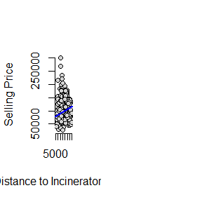

Next, model the $log($`price`$)$ against the $log($`dist`$)$ to estimate the percentage relationship between the two.

$$price = \alpha + \beta_1 dist$$

```r
price_dist_model <- lm(lprice ~ ldist, data = hprice3)
```

Create another model that controls for “quality” variables, such as square footage `area` per house.

$$price = \alpha + \beta_1 dist + \beta_2 area$$

```r
price_area_model <- lm(lprice ~ ldist + larea, data = hprice3)
```

Compare the coefficients of both models. Notice that adding `area` improves the quality of the model, but also reduces the coefficient size of `dist`.

```r
summary(price_dist_model)
summary(price_area_model)
```

|  | *Dependent variable:* |  |
| --- | --- | --- |
|  | lprice |  |
|  | (1) | (2) |
| ldist | 0.31722*** (0.04811) | 0.19623*** (0.03816) |
| larea |  | 0.78368*** (0.05358) |
| Constant | 8.25750*** (0.47383) | 3.49394*** (0.49065) |
| Observations | 321 | 321 |
| R<sup>2</sup> | 0.11994 | 0.47385 |
| Adjusted R<sup>2</sup> | 0.11718 | 0.47054 |
| Residual Std. Error | 0.41170 (df = 319) | 0.31883 (df = 318) |
| F Statistic | 43.47673*** (df = 1; 319) | 143.19470*** (df = 2; 318) |
| *Note:* | p<0.1; p<0.05; p<0.01 |  |

Graphing illustrates the larger coefficient for `area`.

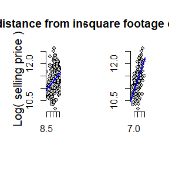

## Chapter 6: Multiple Regression: Further Issues

### **`Example 6.1:` Effects of Pollution on Housing Prices, standardized.**

Load the `hprice2` data and view the documentation.

```r
data("hprice2")
?hprice2
```

Data from *Hedonic Housing Prices and the Demand for Clean Air*, by Harrison, D. and D.L.Rubinfeld, Journal of Environmental Economics and Management 5, 81-102. Diego Garcia, a former Ph.D. student in economics at MIT, kindly provided these data, which he obtained from the book Regression Diagnostics: Identifying Influential Data and Sources of Collinearity, by D.A. Belsey, E. Kuh, and R. Welsch, 1990. New York: Wiley.

$price$: median housing price.

$nox$: Nitrous Oxide concentration; parts per million.

$crime$: number of reported crimes per capita.

$rooms$: average number of rooms in houses in the community.

$dist$: weighted distance of the community to 5 employment centers.

$stratio$: average student-teacher ratio of schools in the community.

$$price = \beta_0 + \beta_1nox + \beta_2crime + \beta_3rooms + \beta_4dist + \beta_5stratio + \mu$$

Estimate the usual `lm` model.

```r
housing_level <- lm(price ~ nox + crime + rooms + dist + stratio, data = hprice2)
```

Estimate the same model, but standardized coefficients by wrapping each variable with R’s `scale` function:

$$\widehat{zprice} = \beta_1znox + \beta_2zcrime + \beta_3zrooms + \beta_4zdist + \beta_5zstratio$$

```r
housing_standardized <- lm(scale(price) ~ 0 + scale(nox) + scale(crime) + scale(rooms) + scale(dist) + scale(stratio), data = hprice2)
```

Compare results, and observe

```r
summary(housing_level)
summary(housing_standardized)
```

|  | *Dependent variable:* |  |
| --- | --- | --- |
|  | price | scale(price) |
|  | (1) | (2) |
| nox | -2,706.43300*** (354.08690) |  |
| crime | -153.60100*** (32.92883) |  |
| rooms | 6,735.49800*** (393.60370) |  |
| dist | -1,026.80600*** (188.10790) |  |
| stratio | -1,149.20400*** (127.42870) |  |
| scale(nox) |  | -0.34045*** (0.04450) |
| scale(crime) |  | -0.14328*** (0.03069) |
| scale(rooms) |  | 0.51389*** (0.03000) |
| scale(dist) |  | -0.23484*** (0.04298) |
| scale(stratio) |  | -0.27028*** (0.02994) |
| Constant | 20,871.13000*** (5,054.59900) |  |
| Observations | 506 | 506 |
| R<sup>2</sup> | 0.63567 | 0.63567 |
| Adjusted R<sup>2</sup> | 0.63202 | 0.63203 |
| Residual Std. Error | 5,586.19800 (df = 500) | 0.60601 (df = 501) |
| F Statistic | 174.47330*** (df = 5; 500) | 174.82220*** (df = 5; 501) |
| *Note:* | p<0.1; p<0.05; p<0.01 |  |

### **`Example 6.2:` Effects of Pollution on Housing Prices, Quadratic Interactive Term**

Modify the housing model from **`example 4.5`**, adding a quadratic term in *rooms*:

$$log(price) = \beta_0 + \beta_1log(nox) + \beta_2log(dist) + \beta_3rooms + \beta_4rooms^2 + \beta_5stratio + \mu$$

```r
housing_model_4.5 <- lm(lprice ~ lnox + log(dist) + rooms + stratio, data = hprice2)

housing_model_6.2 <- lm(lprice ~ lnox + log(dist) + rooms + I(rooms^2) + stratio,
                        data = hprice2)
```

```r
summary(housing_model_4.5)
summary(housing_model_6.2)
```

|  | *Dependent variable:* |  |
| --- | --- | --- |
|  | lprice |  |
|  | (1) | (2) |
| lnox | -0.95354*** (0.11674) | -0.90168*** (0.11469) |
| log(dist) | -0.13434*** (0.04310) | -0.08678** (0.04328) |
| rooms | 0.25453*** (0.01853) | -0.54511*** (0.16545) |
| I(rooms2) |  | 0.06226*** (0.01280) |
| stratio | -0.05245*** (0.00590) | -0.04759*** (0.00585) |
| Constant | 11.08386*** (0.31811) | 13.38548*** (0.56647) |
| Observations | 506 | 506 |
| R<sup>2</sup> | 0.58403 | 0.60281 |
| Adjusted R<sup>2</sup> | 0.58071 | 0.59884 |
| Residual Std. Error | 0.26500 (df = 501) | 0.25921 (df = 500) |
| F Statistic | 175.85520*** (df = 4; 501) | 151.77040*** (df = 5; 500) |
| *Note:* | p<0.1; p<0.05; p<0.01 |  |

Estimate the minimum turning point at which the `rooms` interactive term changes from negative to positive.

$$x = \frac{\hat{\beta_1}}{2\hat{\beta_2}}$$

```r
beta_1 <- summary(housing_model_6.2)$coefficients["rooms",1]
beta_2 <- summary(housing_model_6.2)$coefficients["I(rooms^2)",1]
turning_point <- abs(beta_1 / (2*beta_2))

print(turning_point)
```

```
## [1] 4.37763
```

Compute the percent change across a range of average rooms. Include the smallest, turning point, and largest.

```r
Rooms <- c(min(hprice2$rooms), 4, turning_point, 5, 5.5, 6.45, 7.5, max(hprice2$rooms))
Percent.Change <- 100*(beta_1 + 2*beta_2*Rooms)

kable(data.frame(Rooms, Percent.Change))
```

| Rooms | Percent.Change |
| --- | --- |
| 3.56000 | -10.181324 |
| 4.00000 | -4.702338 |
| 4.37763 | 0.000000 |
| 5.00000 | 7.749903 |
| 5.50000 | 13.976023 |
| 6.45000 | 25.805651 |
| 7.50000 | 38.880503 |
| 8.78000 | 54.819367 |

Graph the log of the selling price against the number of rooms. Superimpose a simple model as well as a quadratic model and examine the difference.

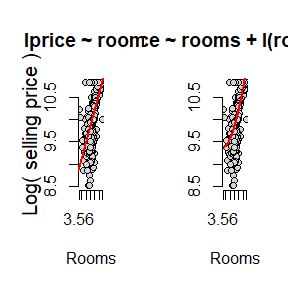

## Chapter 7: Multiple Regression Analysis with Qualitative Information

### **`Example 7.4:` Housing Price Regression, Qualitative Binary variable**

This time, use the `hrprice1` data.

```r
data("hprice1")
```

```r
?hprice1
```

Data collected from the real estate pages of the Boston Globe during 1990. These are homes that sold in the Boston, MA area.

**$lprice:$** Log(house price, $1000s)

**$llotsize:$** Log(size of lot in square feet)

**$lsqrft:$** Log(size of house in square feet)

**$bdrms:$** number of bdrms

**$colonial:$** =1 if home is colonial style

$$\widehat{log(price)} = \beta_0 + \beta_1log(lotsize) + \beta_2log(sqrft) + \beta_3bdrms + \beta_4colonial$$

Estimate the coefficients of the above linear model on the `hprice` data set.

```r
housing_qualitative <- lm(lprice ~ llotsize + lsqrft + bdrms + colonial, data = hprice1)
```

```r
summary(housing_qualitative)
```

|  | *Dependent variable:* |
| --- | --- |
|  | lprice |
| llotsize | 0.16782*** (0.03818) |
| lsqrft | 0.70719*** (0.09280) |
| bdrms | 0.02683 (0.02872) |
| colonial | 0.05380 (0.04477) |
| Constant | -1.34959** (0.65104) |
| Observations | 88 |
| R<sup>2</sup> | 0.64907 |
| Adjusted R<sup>2</sup> | 0.63216 |
| Residual Std. Error | 0.18412 (df = 83) |
| F Statistic | 38.37846*** (df = 4; 83) |
| *Note:* | p<0.1; p<0.05; p<0.01 |

## Chapter 8: Heteroskedasticity

### **`Example 8.9:` Determinants of Personal Computer Ownership**

```r
data("gpa1")

gpa1$parcoll <- as.integer(gpa1$fathcoll==1 | gpa1$mothcoll)

GPA_OLS <- lm(PC ~ hsGPA + ACT + parcoll, data = gpa1)
```

Calculate the weights and then pass them to the `weights` argument.

```r
weights <- GPA_OLS$fitted.values * (1-GPA_OLS$fitted.values)

GPA_WLS <- lm(PC ~ hsGPA + ACT + parcoll, data = gpa1, weights = 1/weights)
```

Compare the OLS and WLS model in the table below:

|  | *Dependent variable:* |  |
| --- | --- | --- |
|  | PC |  |
|  | (1) | (2) |
| hsGPA | 0.06539 (0.13726) | 0.03270 (0.12988) |
| ACT | 0.00056 (0.01550) | 0.00427 (0.01545) |
| parcoll | 0.22105** (0.09296) | 0.21519** (0.08629) |
| Constant | -0.00043 (0.49054) | 0.02621 (0.47665) |
| Observations | 141 | 141 |
| R<sup>2</sup> | 0.04153 | 0.04644 |
| Adjusted R<sup>2</sup> | 0.02054 | 0.02556 |
| Residual Std. Error (df = 137) | 0.48599 | 1.01624 |
| F Statistic (df = 3; 137) | 1.97851 | 2.22404* |
| *Note:* | p<0.1; p<0.05; p<0.01 |  |

## Chapter 9: More on Specification and Data Issues

### **`Example 9.8:` R&D Intensity and Firm Size**

$$rdintens = \beta_0 + \beta_1sales + \beta_2profmarg + \mu$$

From *Businessweek R&D Scoreboard*, October 25, 1991. Load the data and estimate the model.

```r
data("rdchem")

all_rdchem <- lm(rdintens ~ sales + profmarg, data = rdchem)
```

Plotting the data reveals the outlier on the far right of the plot, which will skew the results of our model.

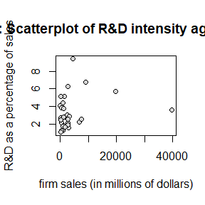

So, we can estimate the model without that data point to gain a better understanding of how `sales` and `profmarg` describe `rdintens` for most firms. We can use the `subset` argument of the linear model function to indicate that we only want to estimate the model using data that is less than the highest sales.

```r
smallest_rdchem <- lm(rdintens ~ sales + profmarg, data = rdchem,
                      subset = (sales < max(sales)))
```

The table below compares the results of both models side by side. By removing the outlier firm, $sales$ become a more significant determination of R&D expenditures.

|  | *Dependent variable:* |  |
| --- | --- | --- |
|  | rdintens |  |
|  | (1) | (2) |
| sales | 0.00005 (0.00004) | 0.00019** (0.00008) |
| profmarg | 0.04462 (0.04618) | 0.04784 (0.04448) |
| Constant | 2.62526*** (0.58553) | 2.29685*** (0.59180) |
| Observations | 32 | 31 |
| R<sup>2</sup> | 0.07612 | 0.17281 |
| Adjusted R<sup>2</sup> | 0.01240 | 0.11372 |
| Residual Std. Error | 1.86205 (df = 29) | 1.79218 (df = 28) |
| F Statistic | 1.19465 (df = 2; 29) | 2.92476* (df = 2; 28) |
| *Note:* | p<0.1; p<0.05; p<0.01 |  |

## Chapter 10: Basic Regression Analysis with Time Series Data

### **`Example 10.2:` Effects of Inflation and Deficits on Interest Rates**

$$\widehat{i3} = \beta_0 + \beta_1inf_t + \beta_2def_t$$
Data from the *Economic Report of the President, 2004*, Tables B-64, B-73, and B-79.

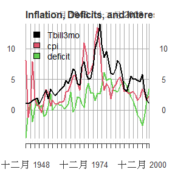

```r
data("intdef") # load data
# load eXtensible Time Series package.
# xts is excellent for time series plots and
# properly indexing time series.
library(xts)
# create xts object from data.frame
# First, index year as yearmon class of monthly data.
# Note: I add 11/12 to set the month to December, end of year.
index <- zoo::as.yearmon(intdef$year + 11/12)
# Next, create the xts object, ordering by the index above.
intdef.xts <- xts(intdef[ ,-1], order.by = index)
# extract 3-month Tbill, inflation, and deficit data
intdef.xts <- intdef.xts[ ,c("i3", "inf", "def")]
# rename with clearer names
colnames(intdef.xts) <- c("Tbill3mo", "cpi", "deficit")
# plot the object, add a title, and place legend at top left.
plot(x = intdef.xts,
     main = "Inflation, Deficits, and Interest Rates",
     legend.loc = "topleft")
```

```r
# Run a Linear regression model
tbill_model <- lm(Tbill3mo ~ cpi + deficit, data = intdef.xts)
```

|  | *Dependent variable:* |
| --- | --- |
|  | Tbill3mo |
| cpi | 0.60587*** (0.08213) |
| deficit | 0.51306*** (0.11838) |
| Constant | 1.73327*** (0.43197) |
| Observations | 56 |
| R<sup>2</sup> | 0.60207 |
| Adjusted R<sup>2</sup> | 0.58705 |
| Residual Std. Error | 1.84316 (df = 53) |
| F Statistic | 40.09424*** (df = 2; 53) |
| *Note:* | p<0.1; p<0.05; p<0.01 |

Now lets update the example with current data, pull from the Federal Reserve Economic Research (FRED) using the [quantmod package](https://CRAN.R-project.org/package=quantmod). Other than the convenient API, the package also formats time series data into [xts: eXtensible Time Series](https://CRAN.R-project.org/package=xts) objects, which add many feature and benefits when working with time series.

```r
# DO NOT RUN
library(quantmod)

# Tbill, 3 month
getSymbols("TB3MS", src = "FRED")
# convert to annual observations and convert index to type `yearmon`.
TB3MS <- to.yearly(TB3MS, OHLC=FALSE, drop.time = TRUE)
index(TB3MS) <- zoo::as.yearmon(index(TB3MS))

# Inflation
getSymbols("FPCPITOTLZGUSA", src = "FRED")
# Convert the index to yearmon and shift FRED's Jan 1st to Dec
index(FPCPITOTLZGUSA) <- zoo::as.yearmon(index(FPCPITOTLZGUSA)) + 11/12
# Rename and update column names
inflation <- FPCPITOTLZGUSA
colnames(inflation) <- "inflation"

## Deficit, percent of GDP: Federal outlays - federal receipts
 # Download outlays
getSymbols("FYFRGDA188S", src = "FRED")
 # Lets move the index from Jan 1st to Dec 30th/31st
index(FYFRGDA188S) <- zoo::as.yearmon(index(FYFRGDA188S)) + 11/12
 # Rename and update column names
outlays <- FYFRGDA188S
colnames(outlays) <- "outlays"

 # Download receipts
getSymbols("FYONGDA188S", src = "FRED")
 # Lets move the index from Jan 1st to Dec 30th/31st
index(FYONGDA188S) <- zoo::as.yearmon(index(FYONGDA188S)) + 11/12
 # Rename and update column names
receipts <- FYONGDA188S
colnames(receipts) <- "receipts"
```

Now that all data has been downloaded, we can calculate the deficit from the federal `outlays` and `receipts` data. Next, we will merge our new `deficit` variable with `inflation` and `TB3MS` variables. As these are all `xts` times series objects, the `merge` function will automatically key off each series time date index, insuring integrity and alignment among each observation and its respective date. Additionally, xts provides easy chart construction with its plot method.

```r
# DO NOT RUN
# create deficits from outlays - receipts
# xts objects respect their indexing and outline the future
deficit <- outlays - receipts
colnames(deficit) <- "deficit"

# Merge and remove leading and trailing NAs for a balanced data matrix
intdef_updated <- merge(TB3MS, inflation, deficit)
intdef_updated <- zoo::na.trim(intdef_updated)

#Plot all
plot(intdef_updated,
     main = "T-bill (3mo rate), inflation, and deficit (% of GDP)",
     legend.loc = "topright",)
```

```r
# DO NOT RUN
updated_model <- lm(TB3MS ~ inflation + deficit, data = intdef_updated)
```

## Chapter 11: Further Issues in Using OLS with with Time Series Data

### **`Example 11.7:` Wages and Productivity**

$$\widehat{log(hrwage_t)} = \beta_0 + \beta_1log(outphr_t) + \beta_2t + \mu_t$$
Data from the *Economic Report of the President, 1989*, Table B-47. The data are for the non-farm business sector.

```r
data("earns")

wage_time <- lm(lhrwage ~ loutphr + t, data = earns)
```

```r
wage_diff <- lm(diff(lhrwage) ~ diff(loutphr), data = earns)
```

|  | *Dependent variable:* |  |
| --- | --- | --- |
|  | lhrwage | diff(lhrwage) |
|  | (1) | (2) |
| loutphr | 1.63964*** (0.09335) |  |
| t | -0.01823*** (0.00175) |  |
| diff(loutphr) |  | 0.80932*** (0.17345) |
| Constant | -5.32845*** (0.37445) | -0.00366 (0.00422) |
| Observations | 41 | 40 |
| R<sup>2</sup> | 0.97122 | 0.36424 |
| Adjusted R<sup>2</sup> | 0.96971 | 0.34750 |
| Residual Std. Error (df = 38) | 0.02854 | 0.01695 |
| F Statistic | 641.22430*** (df = 2; 38) | 21.77054*** (df = 1; 38) |
| *Note:* | p<0.1; p<0.05; p<0.01 |  |

## Chapter 12: Serial Correlation and Heteroskedasticiy in Time Series Regressions

### **`Example 12.8:` Heteroskedasticity and the Efficient Markets Hypothesis**

These are Wednesday closing prices of value-weighted NYSE average, available in many publications. Wooldridge does not recall the particular source used when he collected these data at MIT, but notes probably the easiest way to get similar data is to go to the NYSE web site, [www.nyse.com](https://www.nyse.com/data-and-tech).

$$return_t = \beta_0 + \beta_1return_{t-1} + \mu_t$$

```r
data("nyse")
?nyse
```

```r
return_AR1 <-lm(return ~ return_1, data = nyse)
```

$$\hat{\mu^2_t} = \beta_0 + \beta_1return_{t-1} + residual_t$$

```r
return_mu <- residuals(return_AR1)
mu2_hat_model <- lm(return_mu^2 ~ return_1, data = return_AR1$model)
```

|  | *Dependent variable:* |  |
| --- | --- | --- |
|  | return | return_mu2 |
|  | (1) | (2) |
| return_1 | 0.05890 (0.03802) | -1.10413*** (0.20140) |
| Constant | 0.17963** (0.08074) | 4.65650*** (0.42768) |
| Observations | 689 | 689 |
| R<sup>2</sup> | 0.00348 | 0.04191 |
| Adjusted R<sup>2</sup> | 0.00203 | 0.04052 |
| Residual Std. Error (df = 687) | 2.11040 | 11.17847 |
| F Statistic (df = 1; 687) | 2.39946 | 30.05460*** |
| *Note:* | p<0.1; p<0.05; p<0.01 |  |

### **`Example 12.9:` ARCH in Stock Returns**

$$\hat{\mu^2_t} = \beta_0 + \hat{\mu^2_{t-1}} + residual_t$$

We still have `return_mu` in the working environment so we can use it to create $\hat{\mu^2_t}$, (`mu2_hat`) and $\hat{\mu^2_{t-1}}$ (`mu2_hat_1`). Notice the use `R`’s matrix subset operations to perform the lag operation. We drop the first observation of `mu2_hat` and squared the results. Next, we remove the last observation of `mu2_hat_1` using the subtraction operator combined with a call to the `NROW` function on `return_mu`. Now, both contain $688$ observations and we can estimate a standard linear model.

```r
mu2_hat  <- return_mu[-1]^2
mu2_hat_1 <- return_mu[-NROW(return_mu)]^2
arch_model <- lm(mu2_hat ~ mu2_hat_1)
```

|  | *Dependent variable:* |
| --- | --- |
|  | mu2_hat |
| mu2_hat_1 | 0.33706*** (0.03595) |
| Constant | 2.94743*** (0.44023) |
| Observations | 688 |
| R<sup>2</sup> | 0.11361 |
| Adjusted R<sup>2</sup> | 0.11231 |
| Residual Std. Error | 10.75907 (df = 686) |
| F Statistic | 87.92263*** (df = 1; 686) |
| *Note:* | p<0.1; p<0.05; p<0.01 |

## Chapter 13: Pooling Cross Sections across Time: Simple Panel Data Methods

### **`Example 13.7:` Effect of Drunk Driving Laws on Traffic Fatalities**

Wooldridge collected these data from two sources, the 1992 *Statistical Abstract of the United States* (Tables 1009, 1012) and *A Digest of State Alcohol-Highway Safety Related Legislation*, 1985 and 1990, published by the U.S. National Highway Traffic Safety Administration.
$$\widehat{\Delta{dthrte}} = \beta_0 + \Delta{open} + \Delta{admin}$$

```r
data("traffic1")
?traffic1
```

```r
DD_model <- lm(cdthrte ~ copen + cadmn, data = traffic1)
```

|  | *Dependent variable:* |
| --- | --- |
|  | cdthrte |
| copen | -0.41968** (0.20559) |
| cadmn | -0.15060 (0.11682) |
| Constant | -0.49679*** (0.05243) |
| Observations | 51 |
| R<sup>2</sup> | 0.11867 |
| Adjusted R<sup>2</sup> | 0.08194 |
| Residual Std. Error | 0.34350 (df = 48) |
| F Statistic | 3.23144** (df = 2; 48) |
| *Note:* | p<0.1; p<0.05; p<0.01 |

## Chapter 18: Advanced Time Series Topics

### **`Example 18.8:` FORECASTING THE U.S. UNEMPLOYMENT RATE**

Data from *Economic Report of the President, 2004*, Tables B-42 and B-64.

```r
data("phillips")
?phillips
```

$$\widehat{unemp_t} = \beta_0 + \beta_1unem_{t-1}$$

Estimate the linear model in the usual way and note the use of the `subset` argument to define data equal to and before the year 1996.

```r
phillips_train <- subset(phillips, year <= 1996)

unem_AR1 <- lm(unem ~ unem_1, data = phillips_train)
```

$$\widehat{unemp_t} = \beta_0 + \beta_1unem_{t-1} + \beta_2inf_{t-1}$$

```r
unem_inf_VAR1 <- lm(unem ~ unem_1 + inf_1, data = phillips_train)
```

|  | *Dependent variable:* |  |
| --- | --- | --- |
|  | unem |  |
|  | (1) | (2) |
| unem_1 | 0.73235*** (0.09689) | 0.64703*** (0.08381) |
| inf_1 |  | 0.18358*** (0.04118) |
| Constant | 1.57174*** (0.57712) | 1.30380** (0.48969) |
| Observations | 48 | 48 |
| R<sup>2</sup> | 0.55397 | 0.69059 |
| Adjusted R<sup>2</sup> | 0.54427 | 0.67684 |
| Residual Std. Error | 1.04857 (df = 46) | 0.88298 (df = 45) |
| F Statistic | 57.13184*** (df = 1; 46) | 50.21941*** (df = 2; 45) |
| *Note:* | p<0.1; p<0.05; p<0.01 |  |

Now, use the `subset` argument to create our testing data set containing observation after 1996. Next, pass the both the model object and the test set to the `predict` function for both models. Finally, `cbind` or “column bind” both forecasts as well as the year and unemployment rate of the test set.

```r
phillips_test <- subset(phillips, year >= 1997)

AR1_forecast <- predict.lm(unem_AR1, newdata = phillips_test)
VAR1_forecast <- predict.lm(unem_inf_VAR1, newdata = phillips_test)

kable(cbind(phillips_test[ ,c("year", "unem")], AR1_forecast, VAR1_forecast))
```

|  | year | unem | AR1_forecast | VAR1_forecast |
| --- | --- | --- | --- | --- |
| 50 | 1997 | 4.9 | 5.526452 | 5.348468 |
| 51 | 1998 | 4.5 | 5.160275 | 4.896451 |
| 52 | 1999 | 4.2 | 4.867333 | 4.509137 |
| 53 | 2000 | 4.0 | 4.647627 | 4.425175 |
| 54 | 2001 | 4.8 | 4.501157 | 4.516062 |
| 55 | 2002 | 5.8 | 5.087040 | 4.923537 |
| 56 | 2003 | 6.0 | 5.819394 | 5.350271 |

# Appendix

### Using R for Introductory Econometrics

This is an excellent open source complimentary text to “Introductory Econometrics” by Jeffrey M. Wooldridge and should be your number one resource. This excerpt from the book’s website:

> This book introduces the popular, powerful and free programming language and software package R with a focus on the implementation of standard tools and methods used in econometrics. Unlike other books on similar topics, it does not attempt to provide a self-contained discussion of econometric models and methods. Instead, it builds on the excellent and popular textbook “Introductory Econometrics” by Jeffrey M. Wooldridge.

Heiss, Florian. *Using R for Introductory Econometrics*. ISBN: 979-8648424364, CreateSpace Independent Publishing Platform, 2020, Dusseldorf, Germany.

[url: http://www.urfie.net/](http://www.urfie.net/).

### Applied Econometrics with R

From the publisher’s website:

> This is the first book on applied econometrics using the R system for statistical computing and graphics. It presents hands-on examples for a wide range of econometric models, from classical linear regression models for cross-section, time series or panel data and the common non-linear models of microeconometrics such as logit, probit and tobit models, to recent semiparametric extensions. In addition, it provides a chapter on programming, including simulations, optimization, and an introduction to R tools enabling reproducible econometric research. An R package accompanying this book, AER, is available from the Comprehensive R Archive Network (CRAN) at https://CRAN.R-project.org/package=AER.

Kleiber, Christian and Achim Zeileis. *Applied Econometrics with R*. ISBN 978-0-387-77316-2, Springer-Verlag, 2008, New York. https://link.springer.com/book/10.1007/978-0-387-77318-6

## Bibliography

Jeffrey M. Wooldridge (2020). *Introductory Econometrics: A Modern Approach, 7th edition*. ISBN-13: 978-1-337-55886-0. Mason, Ohio :South-Western Cengage Learning.

Jeffrey A. Ryan and Joshua M. Ulrich (2020). quantmod: Quantitative Financial Modelling Framework. R package version 0.4.18. https://CRAN.R-project.org/package=quantmod

R Core Team (2021). R: A language and environment for statistical computing. R Foundation for Statistical Computing, Vienna, Austria. URL https://www.R-project.org/.

Marek Hlavac (2018). *stargazer: Well-Formatted Regression and Summary Statistics Tables*. R package version 5.2.2. URL: https://CRAN.R-project.org/package=stargazer

van der Loo M (2020). tinytest “A method for deriving information from running R code.” *The R Journal*, Accepted for publication. <URL: https://arxiv.org/abs/2002.07472>.

Yihui Xie (2021). *knitr: A General-Purpose Package for Dynamic Report Generation in R*. R package version 1.33. https://CRAN.R-project.org/package=knitr